# Distributed Data Science

with Sparklyr

[Javier Luraschi](https://github.com/javierluraschi)

August 2018

# Introduction

## Overview

Humanity footprint of digital information grows at exponential rates:

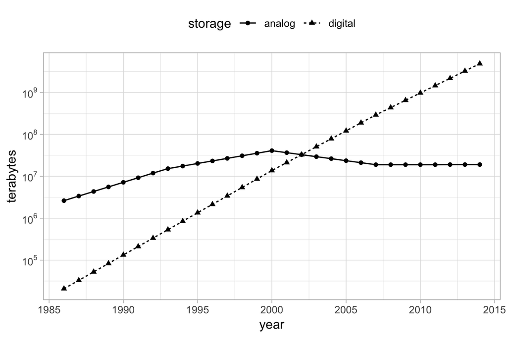

World’s capacity to store information.

Hadoop used disks across machines to process map/reduce operations.

## Spark

> “Apache Spark is a fast and general engine for large-scale data processing.”
- **Data Processing**: Data processing is the collection and manipulation of items of data to produce meaningful information.
- **General**: Spark optimizes and executes parallel generic code, as in, there are no restrictions as to what type of code one can write in Spark.
- **Large-Scale**:

  One can interpret this as cluster-scale, as in, a set of connected computers working together to accomplish specific goals.
- **Fast**:

  Spark is much faster than its predecessor by making efficient use of memory to speed data access while running algorithms at scale.

This is usually known as

**Big Data**

or

**Big Compute.**

## R Language

> R is a programming language and free software environment for statistical computing and graphics.

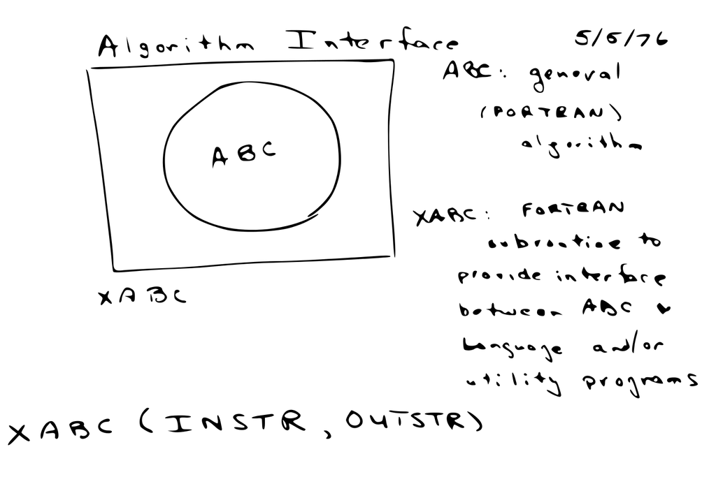

Interface language diagram by John Chambers from useR 2016.

## R Community

Provides a rich package archive provided in [CRAN](https://cran.r-project.org/) and [Bioconductor](https://www.bioconductor.org/): dplyr to manipulate data, cluster to analyze clusters, ggplot2 to visualize data, etc.

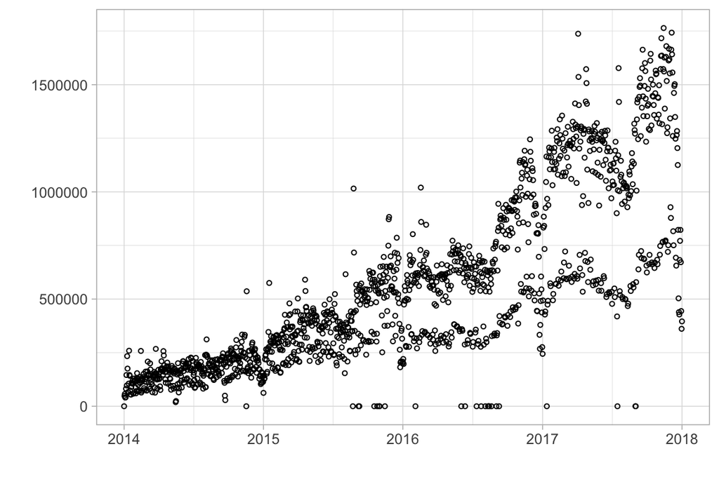

Daily downloads of CRAN packages.

## sparklyr: R interface for Apache Spark

```r
spark_install()                                      # Install Apache Spark
sc <- spark_connect(master = "local")                # Connect to Spark cluster
```

```r
cars_tbl <- spark_read_csv(sc, "cars", "input/")     # Read data in Spark

summarize(cars_tbl, n = n())                         # Count records with dplyr
dbGetQuery(sc, "SELECT count(*) FROM cars")          # Count records with DBI
```

```r
ml_linear_regression(cars_tbl, mpg ~ wt + cyl)       # Perform linear regression

ml_pipeline(sc) %>%                                  # Define Spark pipeline
  ft_r_formula(mpg ~ wt + cyl) %>%                   # Add formula transformation
  ml_linear_regression()                             # Add model to pipeline
```

```r
spark_context(sc) %>% invoke("version")              # Extend sparklyr with Scala
```

```r
spark_apply(cars_tbl, nrow)                          # Extend sparklyr with R
```

```r
stream_read_csv(sc, "input/") %>%                    # Define Spark stream
  filter(mpg > 30) %>%                               # Add dplyr transformation
  stream_write_json("output/")                       # Start processing stream
```

# Modeling

## Algorithms

Modeling algorithms supported in `sparklyr`:

| Algorithm | Function |
| --- | --- |
| Accelerated Failure Time Survival Regression | ml_aft_survival_regression() |
| Alternating Least Squares Factorization | ml_als() |
| Bisecting K-Means Clustering | ml_bisecting_kmeans() |
| Chi-square Hypothesis Testing | ml_chisquare_test() |
| Correlation Matrix | ml_corr() |
| Decision Trees | ml_decision_tree () |
| Frequent Pattern Mining | ml_fpgrowth() |
| Gaussian Mixture Clustering | ml_gaussian_mixture() |
| Generalized Linear Regression | ml_generalized_linear_regression() |
| Gradient-Boosted Trees | ml_gradient_boosted_trees() |
| Isotonic Regression | ml_isotonic_regression() |
| K-Means Clustering | ml_kmeans() |
| Latent Dirichlet Allocation | ml_lda() |
| Linear Regression | ml_linear_regression() |
| Linear Support Vector Machines | ml_linear_svc() |
| Logistic Regression | ml_logistic_regression() |
| Multilayer Perceptron | ml_multilayer_perceptron() |
| Naive-Bayes | ml_naive_bayes() |
| One vs Rest | ml_one_vs_rest() |
| Principal Components Analysis | ml_pca() |
| Random Forests | ml_random_forest() |
| Survival Regression | ml_survival_regression() |

## Transformers

| Transformer | Function |
| --- | --- |
| Binarizer | ft_binarizer() |
| Bucketizer | ft_bucketizer() |
| Chi-Squared Feature Selector | ft_chisq_selector() |
| Vocabulary from Document Collections | ft_count_vectorizer() |
| Discrete Cosine Transform | ft_discrete_cosine_transform() |
| Transformation using dplyr | ft_dplyr_transformer() |
| Hadamard Product | ft_elementwise_product() |
| Feature Hasher | ft_feature_hasher() |
| Term Frequencies using Hashing | export(ft_hashing_tf) |
| Inverse Document Frequency | ft_idf() |
| Imputation for Missing Values | export(ft_imputer) |
| Index to String | ft_index_to_string() |
| Feature Interaction Transform | ft_interaction() |
| Rescale to [-1, 1] Range | ft_max_abs_scaler() |
| Rescale to [min, max] Range | ft_min_max_scaler() |
| Locality Sensitive Hashing | ft_minhash_lsh() |
| Converts to n-grams | ft_ngram() |
| Normalize using the given P-Norm | ft_normalizer() |
| One-Hot Encoding | ft_one_hot_encoder() |
| Feature Expansion in Polynomial Space | ft_polynomial_expansion() |
| Maps to Binned Categorical Features | ft_quantile_discretizer() |
| SQL Transformation | ft_sql_transformer() |
| Standardizes Features using Corrected STD | ft_standard_scaler() |
| Filters out Stop Words | ft_stop_words_remover() |
| Map to Label Indices | ft_string_indexer() |
| Splits by White Spaces | export(ft_tokenizer) |
| Transform Word into Code | ft_word2vec() |

## Gaussian Mixture Clustering

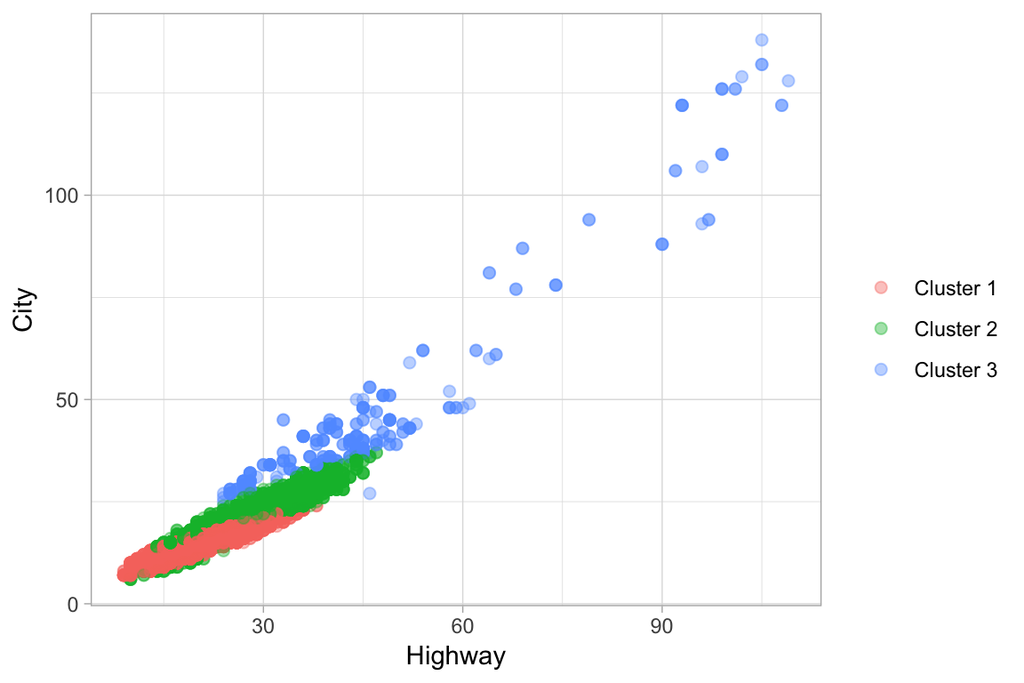

Fuel economy data for 1984-2015 from the US EPA

```r
predictions <- copy_to(sc, fueleconomy::vehicles) %>%
  ml_gaussian_mixture(~ hwy + cty, k = 3) %>%
  ml_predict() %>% collect()

predictions %>%
  ggplot(aes(hwy, cty)) +
  geom_point(aes(hwy, cty, col = factor(prediction)), size = 2, alpha = 0.4) +
  scale_color_discrete(name = "", labels = paste("Cluster", 1:3)) +
  labs(x = "Highway", y = "City") + theme_light()
```

## Broom

Turn your `sparklyr` models into data frames using the `broom` package:

```r
model <- cars_tbl %>%
  ml_linear_regression(mpg ~ wt + cyl)

# Turn a model object into a data frame
broom::tidy(model)
```

```
## # A tibble: 3 x 5
##   term        estimate std.error statistic  p.value
##   <chr>          <dbl>     <dbl>     <dbl>    <dbl>
## 1 (Intercept)    39.7      1.71      23.1  0
## 2 wt             -3.19     0.757     -4.22 0.000222
## 3 cyl            -1.51     0.415     -3.64 0.00106
```

```r
# Construct a single row summary
broom::glance(model)
```

```
## # A tibble: 1 x 5
##   explained.variance mean.absolute.error mean.squared.error r.squared
##                <dbl>               <dbl>              <dbl>     <dbl>
## 1               29.2                1.92               5.97     0.830
## # ... with 1 more variable: root.mean.squared.error <dbl>
```

```r
# Augments each observation in the dataset with the model
broom::augment(model, cars_tbl)
```

# Extensions

## RSparkling

rsparkling provies [H2O](https://www.h2o.ai/) support in Spark using `sparklyr`:

```r
library(rsparkling)
library(sparklyr)
library(h2o)

cars_h2o <- as_h2o_frame(sc, cars_tbl, strict_version_check = FALSE)
h2o.glm(x = c("wt", "cyl"), y = "mpg", training_frame = mtcars_h2o, lambda_search = TRUE)
```

[output not shown]

```
## Model Details:
## ==============
##
## H2ORegressionModel: glm
## Model ID:  GLM_model_R_1533086487173_1
## GLM Model: summary
##     family     link                              regularization
## 1 gaussian identity Elastic Net (alpha = 0.5, lambda = 0.1013 )
##                                                                lambda_search
## 1 nlambda = 100, lambda.max = 10.132, lambda.min = 0.1013, lambda.1se = -1.0
##   number_of_predictors_total number_of_active_predictors
## 1                          2                           2
##   number_of_iterations                                training_frame
## 1                  100 frame_rdd_33_a539369727fb5223dbccfbc5b7894962
##
## Coefficients: glm coefficients
##       names coefficients standardized_coefficients
## 1 Intercept    38.941654                 20.090625
## 2       cyl    -1.468783                 -2.623132
## 3        wt    -3.034558                 -2.969186
##
## H2ORegressionMetrics: glm
## ** Reported on training data. **
##
## MSE:  6.017684
## RMSE:  2.453097
## MAE:  1.940985
## RMSLE:  0.1114801
## Mean Residual Deviance :  6.017684
## R^2 :  0.8289895
## Null Deviance :1126.047
## Null D.o.F. :31
## Residual Deviance :192.5659
## Residual D.o.F. :29
## AIC :156.2425
```

## GraphFrames

[GraphFrames](https://graphframes.github.io/) provides graph algorithms: PageRank, ShortestPaths, etc.

```
GraphFrame
Vertices:
  $ id       <dbl> 12, 12, 59, 59, 1, 20, 20, 45, 45, 8, 8, 9, 9, 26, 26, 37, 37, 47, 47, 16, 16, 71, 71, ...
  $ pagerank <dbl> 0.0058199702, 0.0058199702, 0.0000000000, 0.0000000000, 0.1500000000, 0.0344953402, 0.0...
Edges:
  $ src    <dbl> 13, 13, 13, 13, 13, 13, 13, 13, 13, 13, 13, 13, 13, 13, 13, 13, 58, 58, 58, 58, 58, 58, 5...
  $ dst    <dbl> 22, 22, 22, 22, 22, 22, 22, 22, 22, 22, 22, 22, 22, 22, 22, 22, 65, 65, 65, 65, 65, 65, 6...
  $ weight <dbl> 0.0625, 0.0625, 0.0625, 0.0625, 0.0625, 0.0625, 0.0625, 0.0625, 0.0625, 0.0625, 0.0625, 0...
```

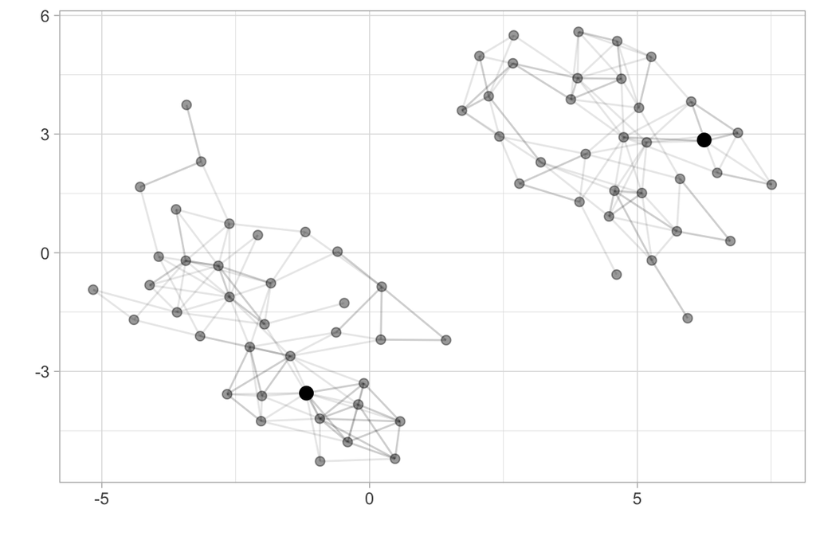

Highschool ggraph dataset with pagerank highlighted.

```r
gf_graphframe(vertices_tbl, edges_tbl) %>% gf_pagerank(reset_prob = 0.15, max_iter = 10L)
```

## Mleap

[Mleap](https://github.com/rstudio/mleap) enables Spark pipelines in production.

```r
# Create pipeline
pipeline_model <- ml_pipeline(sc) %>%
  ft_binarizer("hp", "big_hp", threshold = 100) %>%
  ft_vector_assembler(c("big_hp", "wt", "qsec"), "features") %>%
  ml_gbt_regressor(label_col = "mpg") %>%
  ml_fit(cars_tbl)

# Perform predictions
predictions_tbl <- ml_predict(pipeline_model, mtcars_tbl)

# Export model with mleap
ml_write_bundle(pipeline_model, predictions_tbl, "mtcars_model.zip")
```

Use model outside Spark and productions systems. For instance, in Java:

```java
import ml.combust.mleap.runtime.MleapContext;

// Initialize
BundleBuilder bundleBuilder = new BundleBuilder();
MleapContext context = (new ContextBuilder()).createMleapContext();
Bundle<Transformer> bundle = bundleBuilder.load(new File(request.get("mtcars_model.zip")), context);

// Read into Mleap DataFrame
DefaultLeapFrame inputLeapFrame = new DefaultLeapFrame();

// Perform Mleap transformation
DefaultLeapFrame transformedLeapFrame = bundle.root().transform(inputLeapFrame).get();
```

# Thank You!

## Resources

- therinspark.com:

  If you are new to Spark, this (incomplete) **booklet** will help you get up and running.
- spark.rstudio.com:

  This should be your entry point to learn more about sparklyr, the **documentation** is kept up to date with examples, reference functions and many more relevant resources.
- github.com/rstudio/sparklyr:

  If you believe something needs to get fixed, open a **GitHub** issue or send us a pull request.
- stackoverflow.com/tags/sparklyr:

  For general questions, **Stack Overflow** is a good place to start.
- gitter.im/rstudio/sparklyr:

  For urgent issues or to keep in touch you can chat with us in **Gitter**.